# Assignment02

2025-03-28

## Project Overview

A new lifestyle and retail brand has approached you to help them assess data related to buying patterns in different countries. They are in an expansion mode and would like to present some findings to their investment board regarding the pros and cons related to some key products that they carry. They are also interested also in understanding perspectives from travelers in specified countries to enhance their understanding of how to approach a key segment of their market, vacationers

```r
#install.packages(c("dplyr", "tidyr", "ggplot2", "plotly", "tm"))
#install.packages("corrplot")
#install.packages(c("dplyr", "tidyr", "ggplot2", "plotly", "tm"))
#install.packages("corrplot")
#install.packages(c("SnowballC","syuzhet","wordcloud","wordcloud2","RColorBrewer"))

library(dplyr)
library(tidyr)
library(ggplot2)
library(plotly)
library(tm)
library(corrplot)
library(SnowballC)
library(syuzhet)
library(wordcloud)
library(wordcloud2)
library(RColorBrewer)
```

## Part 1

First we will load in traveler data, and create dataframes for three Caribbean countries: Jamaica, The Bahamas and Trinidad and Tobego

```r
#Clean up data
rm(list=ls())
options(scipen=9999)

#Load in traveler data
tdata <- read.csv("traveler_reviews.csv")
head(tdata, 20)
```

```
##                     Country ReviewedDate DateOfStay
## 1                              21-Aug-16     16-Aug
## 2                    Monaco     3-Jan-16     15-Oct
## 3                  Thailand     9-Aug-15     15-Aug
## 4          Marshall Islands     1-Sep-14     14-Aug
## 5                   Algeria    12-Sep-12     12-Sep
## 6    Bosnia and Herzegovina    14-Sep-18     18-Sep
## 7                   Andorra     9-Sep-18     18-Aug
## 8                 Australia     4-Apr-18     17-May
## 9             Guinea-Bissau    13-Oct-17     17-Aug
## 10                             21-Aug-17     17-Aug
## 11              North Korea    29-Jun-13     13-Jun
## 12   Bosnia and Herzegovina    13-Sep-12     12-Aug
## 13               Costa Rica    28-Jul-17     17-Jul
## 14 United States of America    21-Jun-10     10-Jun
```

[output cut: 27 more lines]

```r
#Create subsets of the data for Jamaica, The Bahamas and Trinidad
jam <- subset(tdata, Country == "Jamaica")
head(jam)
```

```
##      Country ReviewedDate DateOfStay
## 479  Jamaica    23-Oct-12     12-Oct
## 501  Jamaica    21-Nov-14     14-Oct
## 567  Jamaica     2-Dec-15     15-Oct
## 920  Jamaica     6-May-19     19-May
## 983  Jamaica    14-Aug-13     13-Aug
## 1161 Jamaica    15-Jul-08      8-Jul
##                                                                                                                                                                                                                                                                                                          …
## 479                                                                                                                                                                                                                                                                                                      …
## 501                                                                                                                                                                                                                                                                                                      …
## 567                                                                                                                                                                                                                                                                                                      …
## 920                                                                                                                                                                                                                                                                                     All this hotel ha…
## 983                                                                                                                                                                                                                                                                                                      …
## 1161 We stayed at Claudia Ferri's for one night.  The B&amp;B picked us up from the airport and this service was much appreciated, especially since our flight was delayed and we did not land in Pisa until 1 am.  The owner's son was there to meet us.  The next day we went to Florence by train and …
```

```r
baha <- subset(tdata, Country == "The Bahamas")
head(baha)
```

```
##          Country ReviewedDate DateOfStay
## 108  The Bahamas     6-Aug-09      9-Jul
## 211  The Bahamas     8-Jul-17     17-Jul
## 532  The Bahamas     9-Jan-15     14-Dec
## 1056 The Bahamas     9-Nov-16     16-Oct
## 1143 The Bahamas     2-Jun-09      9-May
## 1289 The Bahamas    19-Mar-19     19-Mar
##                                                                                                                                                                                                                                                                                                          …
## 108  No elevator, we did not get any help to carry our heavy bags upstairs. We did not get advice from the reception of how to use the lights in the room and we asked the cleaner who was helpful. The staff at the reception did not smile or talk much. The lady though gave us advise how to go the t…
## 211                                                                                                                                                                                                                                                                                                      …
## 532                                                                                                                                                                                                                                                                                                      …
## 1056                                                                                                                                                                                                                                                                                                     …
## 1143                                                                                                                                                                                                                                                                                                     …
## 1289
```

```r
trini <- subset(tdata, Country == "Trinidad and Tobago")
head(trini)
```

```
##                  Country ReviewedDate DateOfStay
## 125  Trinidad and Tobago     4-Jun-15     15-May
## 465  Trinidad and Tobago     4-Sep-16     16-Aug
## 590  Trinidad and Tobago     1-Mar-15     15-Feb
## 1266 Trinidad and Tobago    29-Jul-13     13-Jul
## 1664 Trinidad and Tobago     2-Apr-13     13-Mar
## 1803 Trinidad and Tobago     4-Jul-15     15-May
##                                                                                                                                                                                                                                                                                                          …
## 125                                                                                                                                                                                                                                                                                                      …
## 465                                                                                                                                                                                                                                                                                                      …
## 590                                                                                                                                                                                                                                                                                                      …
## 1266 My family and I stayed here for a 3 day visit to Pisa. We absolutely loved it aside from the fact that there was no AC (but we were aware of this when we booked it so we can't complain too much). The owners are complete darlings. Simone is incredibly helpful. Don't be surprised if you wake u…
## 1664
## 1803                                                                                                                                                                                                                                                                                                     …
```

# The Bahamas

```r
#Get reviews for wordclouds
baha_rev <- baha$ReviewText

#Convert to corpus and convert to lowercase
btext <- Corpus(VectorSource(baha_rev))
btext <- tm_map(btext, content_transformer(tolower))
#Remove stopwords
btext <- tm_map(btext, removeWords, c(stopwords("english"), "and", "or","hotel"))
#Create wordcloud
btext.dtm <- TermDocumentMatrix(btext)

btext.matrix <- as.matrix(btext.dtm)

bwords <- sort(rowSums(btext.matrix), decreasing=TRUE)

btext.df <- data.frame(word = names(bwords),freq=bwords)
wordcloud2(data=btext.df, size = 0.20, shape="ellipse")
```

[interactive chart not shown]

# Jamaica

```r
#Get reviews for wordclouds
jam_rev <- jam$ReviewText

#Convert to corpus and convert to lowercase
jtext <- Corpus(VectorSource(jam_rev))
jtext <- tm_map(jtext, content_transformer(tolower))
#Remove stopwords
jtext <- tm_map(jtext, removeWords, c(stopwords("english"), "and", "or","hotel"))
#Create wordcloud
jtext.dtm <- TermDocumentMatrix(jtext)

jtext.matrix <- as.matrix(jtext.dtm)

jwords <- sort(rowSums(jtext.matrix), decreasing=TRUE)

jtext.df <- data.frame(word = names(jwords),freq=jwords)
wordcloud2(data=jtext.df, size = 0.20, shape="ellipse")
```

[interactive chart not shown]

# Trinidad

```r
#Get reviews for wordclouds
trini_rev <- trini$ReviewText
head(trini_rev)
```

```
## [1] "-1"
## [2] "Check-in was swift, there was a short queue and we were checked in very quickly. We came earlier than the check-in time initially, the hotel was happy to keep our bags. The room, although small, which is often the case in cities, was clean &amp; the bed was comfortable. The bathroom was equi…
## [3] "Booked with a flight through BA.Three nights bed and breakfast.Big comfy bed, but standard rooms are a bit cosy. The hotel overlooks the train station and bus stops, but the extra glazing keeps all of the noise out.Plenty of storage space plus a safe and minibar. There's even a kettle, which…
## [4] "My family and I stayed here for a 3 day visit to Pisa. We absolutely loved it aside from the fact that there was no AC (but we were aware of this when we booked it so we can't complain too much). The owners are complete darlings. Simone is incredibly helpful. Don't be surprised if you wake u…
## [5] ""
## [6] "What a wonderful find, ideal location. Okay not the most luxurious hotel I've stayed in, but one of the cleanest.Breakfast scrumptious, the smell or warm croissants to wake up to. Lovely coffee made to order and delivered to you table by friendly staff.The guy on the desk was most helpful, g…
```

```r
#Convert to corpus and convert to lowercase
ttext <- Corpus(VectorSource(trini_rev))
ttext <- tm_map(ttext, content_transformer(tolower))
#Remove stopwords
ttext <- tm_map(ttext, removeWords, c(stopwords("english"), "and", "or","hotel"))
```

```r
#Create wordcloud
ttext.dtm <- TermDocumentMatrix(ttext)

ttext.matrix <- as.matrix(ttext.dtm)

twords <- sort(rowSums(ttext.matrix), decreasing=TRUE)

ttext.df <- data.frame(word = names(twords),freq=twords)
wordcloud2(data=ttext.df, size = 0.20, shape="ellipse")
```

[interactive chart not shown]

## Wordcloud Comparisons

Based on the word clouds, it is apparent that most reviews for Jamaica and Trinidad and Tobego are about the hotel room, since the largest word in their wordclouds is “room”. On the other hand, most reviews in the Bahamas discuss “breakfast”

## Sentiment Analysis for each Country

# Bahamas

```r
#Get sentiments and add to table
bsent <- get_nrc_sentiment(baha$ReviewText)
bvibes <- cbind(baha, bsent)
head(bvibes)
```

```
##          Country ReviewedDate DateOfStay
## 108  The Bahamas     6-Aug-09      9-Jul
## 211  The Bahamas     8-Jul-17     17-Jul
## 532  The Bahamas     9-Jan-15     14-Dec
## 1056 The Bahamas     9-Nov-16     16-Oct
## 1143 The Bahamas     2-Jun-09      9-May
## 1289 The Bahamas    19-Mar-19     19-Mar
##                                                                                                                                                                                                                                                                                                          …
## 108  No elevator, we did not get any help to carry our heavy bags upstairs. We did not get advice from the reception of how to use the lights in the room and we asked the cleaner who was helpful. The staff at the reception did not smile or talk much. The lady though gave us advise how to go the t…
## 211                                                                                                                                                                                                                                                                                                      …
## 532                                                                                                                                                                                                                                                                                                      …
## 1056                                                                                                                                                                                                                                                                                                     …
## 1143                                                                                                                                                                                                                                                                                                     …
## 1289
##      anger anticipation disgust fear joy sadness surprise trust negative
## 108      4            4       3    3   7       4        3     8        8
## 211      1            0       0    0   3       0        0     4        1
## 532      0            4       0    0   3       0        1     6        0
## 1056     1            2       0    0   3       0        1     2        1
## 1143     0            4       0    0   4       0        2     7        0
## 1289     0            0       0    0   0       0        0     0        0
##      positive
## 108        13
## 211         6
## 532         8
## 1056        6
## 1143       10
## 1289        0
```

```r
#Determine dominant sentiment
count <- colSums(bsent)
most <- names(count)[which.max(count)]
cat("The most common sentiment in The Bahamas is", most)
```

```
## The most common sentiment in The Bahamas is positive
```

#Jamaica

```r
#Get sentiments and add to table
jsent <- get_nrc_sentiment(jam$ReviewText)
jvibes <- cbind(jam, jsent)
head(jvibes)
```

```
##      Country ReviewedDate DateOfStay
## 479  Jamaica    23-Oct-12     12-Oct
## 501  Jamaica    21-Nov-14     14-Oct
## 567  Jamaica     2-Dec-15     15-Oct
## 920  Jamaica     6-May-19     19-May
## 983  Jamaica    14-Aug-13     13-Aug
## 1161 Jamaica    15-Jul-08      8-Jul
##                                                                                                                                                                                                                                                                                                          …
## 479                                                                                                                                                                                                                                                                                                      …
## 501                                                                                                                                                                                                                                                                                                      …
## 567                                                                                                                                                                                                                                                                                                      …
## 920                                                                                                                                                                                                                                                                                     All this hotel ha…
## 983                                                                                                                                                                                                                                                                                                      …
## 1161 We stayed at Claudia Ferri's for one night.  The B&amp;B picked us up from the airport and this service was much appreciated, especially since our flight was delayed and we did not land in Pisa until 1 am.  The owner's son was there to meet us.  The next day we went to Florence by train and …
##      anger anticipation disgust fear joy sadness surprise trust negative
## 479      0            3       0    2   1       1        0     3        3
## 501      2            1       2    1   1       2        1     1        3
## 567      1            4       0    1   4       0        1     5        0
## 920      0            2       1    0   4       1        1     3        1
## 983      0            1       0    0   2       0        0     2        0
## 1161     0            2       0    0   4       1        1     5        2
##      positive
## 479         4
## 501         2
## 567         6
## 920         6
## 983         3
## 1161        9
```

```r
#Determine dominant sentiment
count <- colSums(jsent)
most <- names(count)[which.max(count)]
cat("The most common sentiment in Jamaica is", most)
```

```
## The most common sentiment in Jamaica is positive
```

#Trinidad and Tobego

```r
#Get sentiments and add to table
tsent <- get_nrc_sentiment(trini$ReviewText)
tvibes <- cbind(trini, tsent)
head(tvibes)
```

```
##                  Country ReviewedDate DateOfStay
## 125  Trinidad and Tobago     4-Jun-15     15-May
## 465  Trinidad and Tobago     4-Sep-16     16-Aug
## 590  Trinidad and Tobago     1-Mar-15     15-Feb
## 1266 Trinidad and Tobago    29-Jul-13     13-Jul
## 1664 Trinidad and Tobago     2-Apr-13     13-Mar
## 1803 Trinidad and Tobago     4-Jul-15     15-May
##                                                                                                                                                                                                                                                                                                          …
## 125                                                                                                                                                                                                                                                                                                      …
## 465                                                                                                                                                                                                                                                                                                      …
## 590                                                                                                                                                                                                                                                                                                      …
## 1266 My family and I stayed here for a 3 day visit to Pisa. We absolutely loved it aside from the fact that there was no AC (but we were aware of this when we booked it so we can't complain too much). The owners are complete darlings. Simone is incredibly helpful. Don't be surprised if you wake u…
## 1664
## 1803                                                                                                                                                                                                                                                                                                     …
##      anger anticipation disgust fear joy sadness surprise trust negative
## 125      0            0       0    0   0       0        0     0        0
## 465      0            3       0    1   3       1        0     7        3
## 590      0            3       0    0   3       0        3     5        2
## 1266     1            3       2    0   4       4        2     9        6
## 1664     0            0       0    0   0       0        0     0        0
## 1803     1            2       1    1   5       2        2     6        2
##      positive
## 125         0
## 465        12
## 590         9
## 1266       10
## 1664        0
## 1803       11
```

```r
#Determine dominant sentiment
count <- colSums(tsent)
most <- names(count)[which.max(count)]
cat("The most common sentiment in Trinidad and Tobago is", most)
```

```
## The most common sentiment in Trinidad and Tobago is positive
```

#————-PART 2

#————- Deleting stored Objects and Importing csv file

```r
rm(list=ls())
options(scipen=9999)
sales.df <- read.csv("sales_data03.csv", stringsAsFactors = FALSE)
head(sales.df)
```

```
##     X.1             Region   Country          X Sales.Channel Order.Priority
## 1 71605 Sub-Saharan Africa   Lesotho     Cereal        Online              C
## 2 46486               Asia Indonesia  Baby Food        Online              C
## 3 95794
## 4 11824             Europe    Norway     Fruits       Offline              H
## 5 15718             Europe    Latvia Vegetables       Offline              M
## 6 95342
##   Order.Date  Order.ID Ship.Date Units.Sold Unit.Price Unit.Cost Total.Revenue
## 1   5/5/2012 726463067 6/20/2012       5420      205.7    117.11       1114894
## 2   4/4/2012 766172206 4/17/2012       6237     255.28    159.42    1592181.36
## 3
## 4  3/31/2012 180996596  4/8/2012       9770       9.33      6.92       91154.1
## 5  2/23/2016 624427974 3/23/2016        968     154.06     90.93     149130.08
## 6
##   Total.Cost Total.Profit
## 1   634736.2     480157.8
## 2  994302.54    597878.82
## 3
## 4    67608.4      23545.7
## 5   88020.24     61109.84
## 6
```

#————– Deleting rows entirely consisting of ““, NA or”k”s.

```r
#Step 1 - Removing empty rows
noNARow <- sales.df[rowSums(is.na(sales.df[, -1]) | sales.df[, -1] == "" | sales.df[, -1] == "k") != (ncol(sales.df) - 1), ]
```

#—————- Checking how dirty the Region feature is and extracting only the valid regions

```r
uniqueValues <- unique(noNARow[,"Region"])
print(uniqueValues)
```

```
##  [1] "Sub-Saharan Africa"                "Asia"
##  [3] "Europe"                            "Australia and Oceania"
##  [5] "Central America and the Caribbean" "Middle East and North Africa"
##  [7] "?"                                 "North America"
##  [9] "\"\""                              ""
```

```r
validPlaces <- c("Sub-Saharan Africa", "Asia" , "Europe" , "Australia and Oceania", "Central America and the Caribbean",
                 "Middle East and North Africa", "North America")

print(validPlaces)
```

```
## [1] "Sub-Saharan Africa"                "Asia"
## [3] "Europe"                            "Australia and Oceania"
## [5] "Central America and the Caribbean" "Middle East and North Africa"
## [7] "North America"
```

#——————- Removing extra places at the end of countries eg. “Saint Kitts and Nevis” and also getting all the countries

```r
noNARow$Country <- trimws(noNARow$Country)
uniqueValues <- unique(noNARow[,"Country"])
print(uniqueValues)
```

```
##   [1] "Lesotho"                          "Indonesia"
##   [3] "Norway"                           "Latvia"
##   [5] "Uzbekistan"                       "Papua New Guinea"
##   [7] "Serbia"                           "Panama"
##   [9] "Jamaica"                          "Brunei"
##  [11] "Senegal"                          "San Marino"
##  [13] "Vanuatu"                          "East Timor"
##  [15] "Slovenia"                         "Slovakia"
##  [17] "Croatia"                          "Niger"
##  [19] "Austria"                          "Tanzania"
##  [21] "Eritrea"                          "Luxembourg"
##  [23] "Sao Tome and Principe"            "Mali"
##  [25] "Kuwait"                           "Tuvalu"
##  [27] "Saudi Arabia"                     "Cambodia"
##  [29] "Kyrgyzstan"                       "Central African Republic"
```

[output cut: 78 more lines]

#——————- As all entries under Countries are valid we can extract the missing values or the region by using domain knowledge #here we assign each country to their region

```r
countryRegionMap <- c(
  "Lesotho" = "Sub-Saharan Africa", "Indonesia" = "Asia", "Norway" = "Europe",
  "Latvia" = "Europe", "Uzbekistan" = "Asia", "Papua New Guinea" = "Australia and Oceania",
  "Serbia" = "Europe", "Panama" = "Central America and the Caribbean", "Jamaica" = "Central America and the Caribbean",
  "Brunei" = "Asia", "Senegal" = "Sub-Saharan Africa", "San Marino" = "Europe",
  "Vanuatu" = "Australia and Oceania", "East Timor" = "Asia", "Slovenia" = "Europe",
  "Slovakia" = "Europe", "Croatia" = "Europe", "Niger" = "Sub-Saharan Africa",
  "Austria" = "Europe", "Tanzania" = "Sub-Saharan Africa", "Eritrea" = "Sub-Saharan Africa",
  "Luxembourg" = "Europe", "Sao Tome and Principe" = "Sub-Saharan Africa", "Mali" = "Sub-Saharan Africa",
  "Kuwait" = "Middle East and North Africa", "Tuvalu" = "Australia and Oceania", "Saudi Arabia" = "Middle East and North Africa",
  "Cambodia" = "Asia", "Kyrgyzstan" = "Asia", "Central African Republic" = "Sub-Saharan Africa",
  "Denmark" = "Europe", "Madagascar" = "Sub-Saharan Africa", "Hungary" = "Europe",
  "United Kingdom" = "Europe", "Ethiopia" = "Sub-Saharan Africa", "South Korea" = "Asia",
  "Mexico" = "North America", "United Arab Emirates" = "Middle East and North Africa",
  "Sweden" = "Europe", "Syria" = "Middle East and North Africa", "Mauritius" = "Sub-Saharan Africa",
  "Honduras" = "Central America and the Caribbean", "Comoros" = "Sub-Saharan Africa",
  "Mozambique" = "Sub-Saharan Africa", "Qatar" = "Middle East and North Africa",
  "Vietnam" = "Asia", "Sri Lanka" = "Asia", "Bosnia and Herzegovina" = "Europe",
  "Costa Rica" = "Central America and the Caribbean", "Cape Verde" = "Sub-Saharan Africa",
  "Japan" = "Asia", "Italy" = "Europe", "Samoa" = "Australia and Oceania",
  "Guatemala" = "Central America and the Caribbean", "South Africa" = "Sub-Saharan Africa",
  "Barbados" = "Central America and the Caribbean", "Portugal" = "Europe",
  "Swaziland" = "Sub-Saharan Africa", "Mauritania" = "Sub-Saharan Africa",
  "New Zealand" = "Australia and Oceania", "Belize" = "Central America and the Caribbean",
  "Tonga" = "Australia and Oceania", "Georgia" = "Europe", "Taiwan" = "Asia",
  "Bhutan" = "Asia", "Kenya" = "Sub-Saharan Africa", "Algeria" = "Middle East and North Africa",
  "Kiribati" = "Australia and Oceania", "Palau" = "Australia and Oceania",
  "Sierra Leone" = "Sub-Saharan Africa", "Bangladesh" = "Asia", "Thailand" = "Asia",
  "Yemen" = "Middle East and North Africa", "Afghanistan" = "Asia",
  "Trinidad and Tobago" = "Central America and the Caribbean",
  "United States of America" = "North America", "Germany" = "Europe",
  "Andorra" = "Europe", "Turkey" = "Asia", "Singapore" = "Asia",
  "Switzerland" = "Europe", "France" = "Europe", "Uganda" = "Sub-Saharan Africa",
  "Liberia" = "Sub-Saharan Africa", "Kosovo" = "Europe", "Macedonia" = "Europe",
  "Equatorial Guinea" = "Sub-Saharan Africa", "Solomon Islands" = "Australia and Oceania",
  "Turkmenistan" = "Asia", "Belarus" = "Europe", "Netherlands" = "Europe",
  "Romania" = "Europe", "Russia" = "Europe", "Togo" = "Sub-Saharan Africa",
  "Lebanon" = "Middle East and North Africa", "Bulgaria" = "Europe",
  "Cyprus" = "Europe", "Australia" = "Australia and Oceania", "Monaco" = "Europe",
  "Malawi" = "Sub-Saharan Africa", "Saint Lucia" = "Central America and the Caribbean",
  "Montenegro" = "Europe", "Sudan" = "Sub-Saharan Africa", "Nauru" = "Australia and Oceania",
  "Zambia" = "Sub-Saharan Africa", "Kazakhstan" = "Asia", "Oman" = "Middle East and North Africa",
  "Vatican City" = "Europe", "Chad" = "Sub-Saharan Africa", "Armenia" = "Asia",
  "Belgium" = "Europe", "Antigua and Barbuda" = "Central America and the Caribbean",
  "Myanmar" = "Asia", "Iraq" = "Middle East and North Africa",
  "Burundi" = "Sub-Saharan Africa", "Finland" = "Europe", "Tajikistan" = "Asia",
  "Cuba" = "Central America and the Caribbean", "Dominica" = "Central America and the Caribbean",
  "Czech Republic" = "Europe", "Poland" = "Europe", "Malaysia" = "Asia",
  "Greenland" = "North America", "Benin" = "Sub-Saharan Africa", "Azerbaijan" = "Asia",
  "Iran" = "Middle East and North Africa", "Mongolia" = "Asia",
  "Lithuania" = "Europe", "Guinea" = "Sub-Saharan Africa",
  "Estonia" = "Europe", "Tunisia" = "Middle East and North Africa",
  "Saint Vincent and the Grenadines" = "Central America and the Caribbean",
  "North Korea" = "Asia", "Malta" = "Europe", "Liechtenstein" = "Europe",
  "The Bahamas" = "Central America and the Caribbean", "Ukraine" = "Europe",
  "Federated States of Micronesia" = "Australia and Oceania",
  "South Sudan" = "Sub-Saharan Africa", "Moldova" = "Europe",
  "Philippines" = "Asia", "The Gambia" = "Sub-Saharan Africa",
  "Israel" = "Middle East and North Africa", "Burkina Faso" = "Sub-Saharan Africa",
  "Djibouti" = "Sub-Saharan Africa", "Bahrain" = "Middle East and North Africa",
  "Botswana" = "Sub-Saharan Africa", "Haiti" = "Central America and the Caribbean",
  "Somalia" = "Sub-Saharan Africa", "Namibia" = "Sub-Saharan Africa",
  "Marshall Islands" = "Australia and Oceania", "Greece" = "Europe",
  "Spain" = "Europe", "Saint Kitts and Nevis" = "Central America and the Caribbean",
  "Seychelles" = "Sub-Saharan Africa", "Dominican Republic" = "Central America and the Caribbean",
  "Albania" = "Europe", "Rwanda" = "Sub-Saharan Africa", "Gabon" = "Sub-Saharan Africa",
  "Canada" = "North America", "Ghana" = "Sub-Saharan Africa",
  "Morocco" = "Middle East and North Africa", "Guinea-Bissau" = "Sub-Saharan Africa",
  "Ireland" = "Europe", "India" = "Asia", "Democratic Republic of the Congo" = "Sub-Saharan Africa",
  "Iceland" = "Europe", "Pakistan" = "Asia", "Laos" = "Asia",
  "Cameroon" = "Sub-Saharan Africa", "Cote d'Ivoire" = "Sub-Saharan Africa",
  "Grenada" = "Central America and the Caribbean", "Maldives" = "Asia",
  "Nepal" = "Asia", "Fiji" = "Australia and Oceania", "Nicaragua" = "Central America and the Caribbean",
  "Jordan" = "Middle East and North Africa", "El Salvador" = "Central America and the Caribbean",
  "Egypt" = "Middle East and North Africa", "Republic of the Congo" = "Sub-Saharan Africa",
  "Angola" = "Sub-Saharan Africa", "Zimbabwe" = "Sub-Saharan Africa",
  "Nigeria" = "Sub-Saharan Africa"
)
```

#—————————- Invalid Region entries are replaced with the correct Regions based on their country

```r
fixedCountries <- noNARow
fixedCountries$Region <- ifelse(noNARow$Region %in% validPlaces, noNARow$Region, countryRegionMap[noNARow$Country])

uniqueValues <- unique(fixedCountries[,"Region"])
print(uniqueValues)
```

```
## [1] "Sub-Saharan Africa"                "Asia"
## [3] "Europe"                            "Australia and Oceania"
## [5] "Central America and the Caribbean" "Middle East and North Africa"
## [7] "North America"
```

#————————- X is reviewed but we decided to view “None” as the option “other”

```r
#Note - None is one of the options
uniqueValues <- unique(fixedCountries[,"X"])
print(uniqueValues)
```

```
##  [1] "Cereal"          "Baby Food"       "Fruits"          "Vegetables"
##  [5] "Clothes"         "Household"       "Meat"            "Snacks"
##  [9] "Cosmetics"       "Personal Care"   "Office Supplies" "Beverages"
## [13] "None"
```

#————————- Sales.Channel is checked on what dirty values it has.

```r
#Note - Yes is one of the options
uniqueValues <- unique(fixedCountries[,"Sales.Channel"])
print(uniqueValues)
```

```
## [1] "Online"  "Offline" "YES"     ""
```

```r
fixedCountries[fixedCountries$Sales.Channel == "", ]
```

```
##        X.1                            Region      Country               X
## 275   6093                              Asia        Japan          Cereal
## 2261  6041                              Asia        China            Meat
## 3197  6025                Sub-Saharan Africa Burkina Faso   Personal Care
## 4544  6074      Middle East and North Africa      Morocco         Clothes
## 4623  6022                            Europe      Estonia          Cereal
## 5236  6077                Sub-Saharan Africa   The Gambia Office Supplies
## 7292  6069 Central America and the Caribbean    Nicaragua       Household
## 7494  6097                Sub-Saharan Africa     Djibouti       Baby Food
## 8138  6071                            Europe      Armenia      Vegetables
## 9920  6028                            Europe      Iceland          Cereal
## 10194 6046 Central America and the Caribbean      Grenada         Clothes
## 11177 6082                            Europe      Austria         Clothes
## 12157 6109                              Asia       Bhutan          Snacks
## 12440 6101                Sub-Saharan Africa     Cameroon            Meat
```

[output cut: 60 more lines]

```r
# Print the unique values in the Sales.Channel column to check
uniqueValue <- unique(fixedCountries[,"Sales.Channel"])
print(uniqueValue)
```

```
## [1] "Online"  "Offline" "YES"     ""
```

#———————– Using predictions we predict if the Sales.Channel based on the country and item type

```r
fixedCountries$Sales.Channel <- tolower(fixedCountries$Sales.Channel)

fixedCountries$Sales.Channel <- ifelse(fixedCountries$Sales.Channel %in% c("yes", ""), NA, fixedCountries$Sales.Channel)

fixedCountries$Sales.Channel <- factor(fixedCountries$Sales.Channel, levels = c("offline", "online"))

print(table(fixedCountries$Sales.Channel, useNA = "always"))
```

```
##
## offline  online    <NA>
##    9278    9081      80
```

```r
train_data <- fixedCountries %>% filter(!is.na(Sales.Channel))

if (length(unique(train_data$Sales.Channel)) > 1) {
    model <- glm(Sales.Channel ~ Country + X, data = train_data, family = binomial, na.action = na.exclude)

    missing_indices <- which(is.na(fixedCountries$Sales.Channel))
    fixedCountries$PredictedProb <- predict(model, newdata = fixedCountries, type = "response")

    fixedCountries$Sales.Channel[missing_indices] <- ifelse(fixedCountries$PredictedProb[missing_indices] > 0.5, "online", "offline")

    fixedCountries$Sales.Channel <- factor(fixedCountries$Sales.Channel, levels = c("offline", "online"))

    fixedCountries <- fixedCountries %>% select(-PredictedProb)
} else {
    warning("Not enough unique levels in Sales.Channel to fit the model. Check data cleaning steps!")
}

print(table(fixedCountries$Sales.Channel, useNA = "always"))
```

```
##
## offline  online    <NA>
##    9326    9113       0
```

#————————- Order.Date and Ship.Date are compared to check for errors

```r
fixedCountries$Order.Date <- as.Date(fixedCountries$Order.Date, format="%m/%d/%Y")
fixedCountries$Ship.Date <- as.Date(fixedCountries$Ship.Date, format="%m/%d/%Y")

all(fixedCountries$Order.Date <= fixedCountries$Ship.Date)
```

```
## [1] TRUE
```

```r
#invalid_rows <- fixedCountries[fixedCountries$Order.Date > fixedCountries$Ship.Date, ]

# Print the problematic rows
#print(invalid_rows)
```

#————————– Region

```r
summary(fixedCountries$Region)
```

```
##    Length     Class      Mode
##     18439 character character
```

```r
uniqueValues <- unique(fixedCountries[,"Region"])
print(uniqueValues)
```

```
## [1] "Sub-Saharan Africa"                "Asia"
## [3] "Europe"                            "Australia and Oceania"
## [5] "Central America and the Caribbean" "Middle East and North Africa"
## [7] "North America"
```

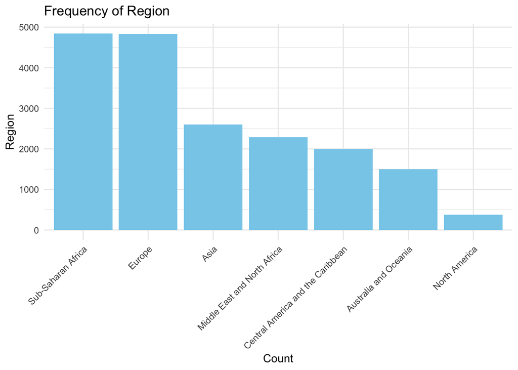

```r
product_counts <- fixedCountries %>%
  count(Region)

ggplot(product_counts, aes(x = reorder(Region, -n), y = n)) +
  geom_bar(stat = "identity", fill = "skyblue") +
  labs(
    title = "Frequency of Region",
    x = "Count",
    y = "Region"
  ) +
  theme_minimal() +
  theme(axis.text.x = element_text(angle = 45, hjust = 1))  # Rotate x-labels
```

#———————————————– Country

```r
summary(fixedCountries$Country)
```

```
##    Length     Class      Mode
##     18439 character character
```

```r
uniqueValues <- unique(fixedCountries[,"Country"])
print(uniqueValues)
```

```
##   [1] "Lesotho"                          "Indonesia"
##   [3] "Norway"                           "Latvia"
##   [5] "Uzbekistan"                       "Papua New Guinea"
##   [7] "Serbia"                           "Panama"
##   [9] "Jamaica"                          "Brunei"
##  [11] "Senegal"                          "San Marino"
##  [13] "Vanuatu"                          "East Timor"
##  [15] "Slovenia"                         "Slovakia"
##  [17] "Croatia"                          "Niger"
##  [19] "Austria"                          "Tanzania"
##  [21] "Eritrea"                          "Luxembourg"
##  [23] "Sao Tome and Principe"            "Mali"
##  [25] "Kuwait"                           "Tuvalu"
##  [27] "Saudi Arabia"                     "Cambodia"
##  [29] "Kyrgyzstan"                       "Central African Republic"
```

[output cut: 78 more lines]

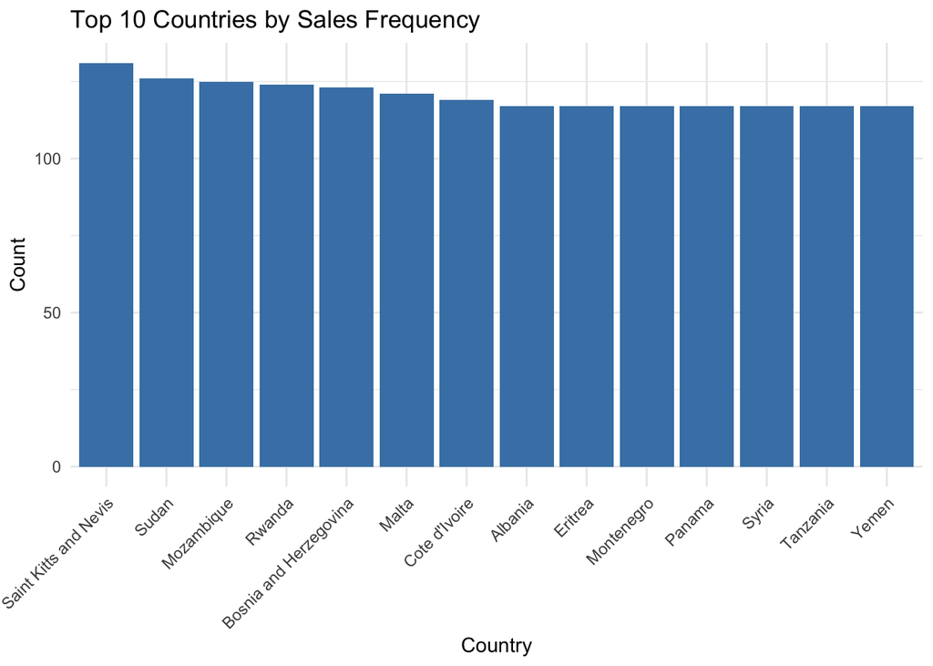

```r
top_countries <- fixedCountries %>%
  count(Country) %>%
  top_n(10, n)

ggplot(top_countries, aes(x = reorder(Country, -n), y = n)) +
  geom_bar(stat = "identity", fill = "steelblue") +
  labs(title = "Top 10 Countries by Sales Frequency", x = "Country", y = "Count") +
  theme_minimal() +
  theme(axis.text.x = element_text(angle = 45, hjust = 1))
```

#——————————— X

```r
summary(fixedCountries$X)
```

```
##    Length     Class      Mode
##     18439 character character
```

```r
uniqueValues <- unique(fixedCountries[,"X"])
print(uniqueValues)
```

```
##  [1] "Cereal"          "Baby Food"       "Fruits"          "Vegetables"
##  [5] "Clothes"         "Household"       "Meat"            "Snacks"
##  [9] "Cosmetics"       "Personal Care"   "Office Supplies" "Beverages"
## [13] "None"
```

#————————– It was noticed that Unit.Cost only relates to one type of item. Using this we are able to look at the price # to figure out the X eg 117.11 is only related to cereal

```r
cost_to_product <- fixedCountries %>%
  filter(X != "None" & !is.na(X) & X != "") %>%
  group_by(Unit.Cost) %>%
  summarize(
    potential_product = first(X),
    product_count = n_distinct(X)
  ) %>%
  filter(product_count == 1)

fixedCountries <- fixedCountries %>%
  left_join(cost_to_product, by = "Unit.Cost") %>%
  mutate(
    X = case_when(
      X == "None" & !is.na(potential_product) ~ potential_product,
      TRUE ~ X
    )
  ) %>%
  select(-potential_product, -product_count)


fixedCountries <- fixedCountries %>%
  mutate(X = ifelse(X == "None", "Other", X))
```

```r
summary(fixedCountries$X)
```

```
##    Length     Class      Mode
##     18439 character character
```

```r
uniqueValues <- unique(fixedCountries[,"X"])
print(uniqueValues)
```

```
##  [1] "Cereal"          "Baby Food"       "Fruits"          "Vegetables"
##  [5] "Clothes"         "Household"       "Meat"            "Snacks"
##  [9] "Cosmetics"       "Personal Care"   "Office Supplies" "Beverages"
```

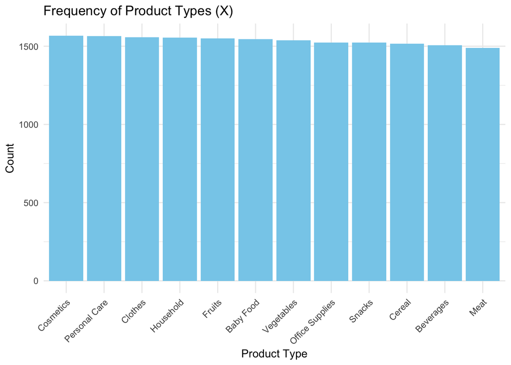

```r
product_counts <- fixedCountries %>%
  count(X)

ggplot(product_counts, aes(x = reorder(X, -n), y = n)) +
  geom_bar(stat = "identity", fill = "skyblue") +
  labs(
    title = "Frequency of Product Types (X)",
    x = "Product Type",
    y = "Count"
  ) +
  theme_minimal() +
  theme(axis.text.x = element_text(angle = 45, hjust = 1))  # Rotate x-labels
```

#———————————- Sales.Channel

```r
summary(fixedCountries$Sales.Channel)
```

```
## offline  online
##    9326    9113
```

```r
uniqueValues <- unique(fixedCountries[,"Sales.Channel"])
print(uniqueValues)
```

```
## [1] online  offline
## Levels: offline online
```

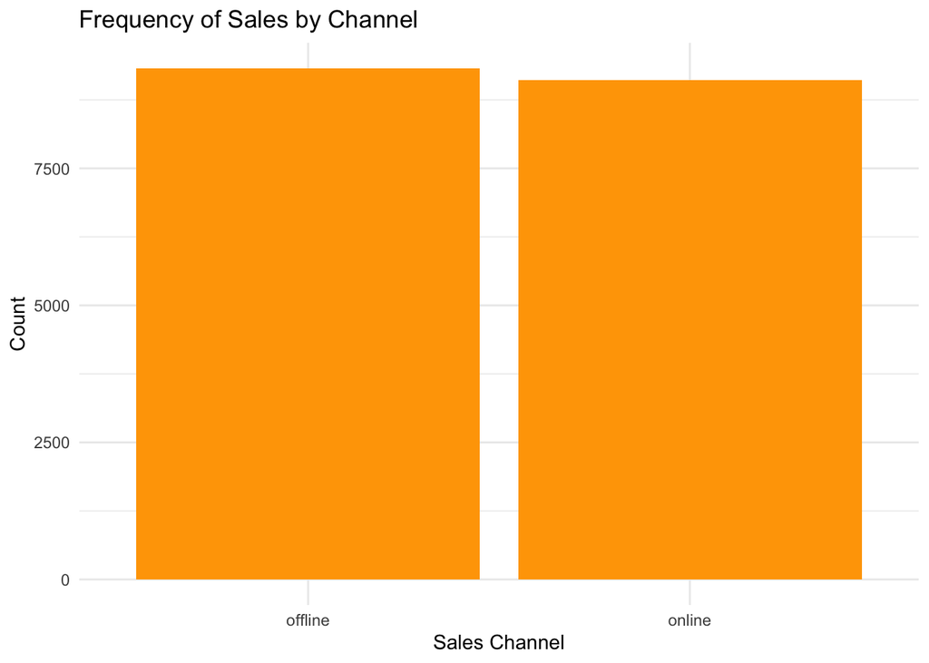

```r
channel_counts <- fixedCountries %>%
  count(Sales.Channel) %>%
  arrange(desc(n))  # Sort by frequency (descending)

ggplot(channel_counts, aes(x = Sales.Channel, y = n)) +
  geom_bar(stat = "identity", fill = "orange") +
  labs(title = "Frequency of Sales by Channel", x = "Sales Channel", y = "Count") +
  theme_minimal()
```

#——————————- Order.Priority

```r
summary(fixedCountries$Order.Priority)
```

```
##    Length     Class      Mode
##     18439 character character
```

```r
uniqueValues <- unique(fixedCountries[,"Order.Priority"])
print(uniqueValues)
```

```
## [1] "C" "H" "M" "L"
```

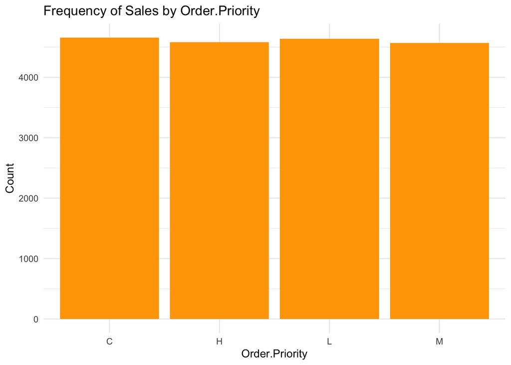

```r
channel_counts <- fixedCountries %>%
  count(Order.Priority) %>%
  arrange(desc(n))  # Sort by frequency (descending)

ggplot(channel_counts, aes(x = Order.Priority, y = n)) +
  geom_bar(stat = "identity", fill = "orange") +
  labs(title = "Frequency of Sales by Order.Priority", x = "Order.Priority", y = "Count") +
  theme_minimal()
```

#———————————- Order.Date

```r
summary(fixedCountries$Order.Date)
```

```
##         Min.      1st Qu.       Median         Mean      3rd Qu.         Max.
## "2010-01-01" "2011-12-01" "2013-10-28" "2013-10-20" "2015-09-11" "2017-07-28"
```

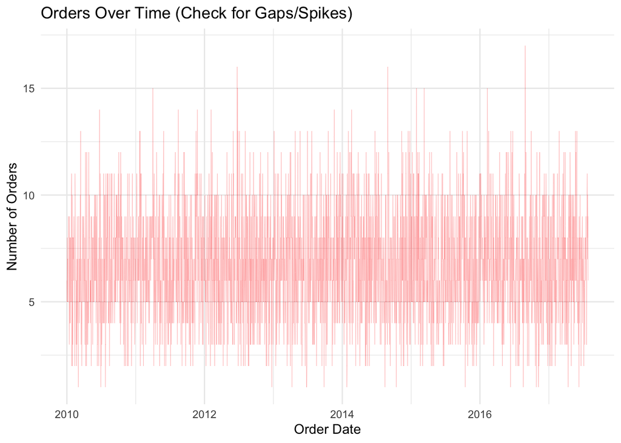

```r
ggplot(fixedCountries, aes(x = Order.Date)) +
  geom_line(stat = "count", color = "red", linewidth = .05) +  # Count orders per date
  labs(
    title = "Orders Over Time (Check for Gaps/Spikes)",
    x = "Order Date",
    y = "Number of Orders"
  ) +
  theme_minimal()
```

#———————————- Ship.Date

```r
summary(fixedCountries$Ship.Date)
```

```
##         Min.      1st Qu.       Median         Mean      3rd Qu.         Max.
## "2010-01-07" "2011-12-27" "2013-11-26" "2013-11-14" "2015-10-07" "2017-09-09"
```

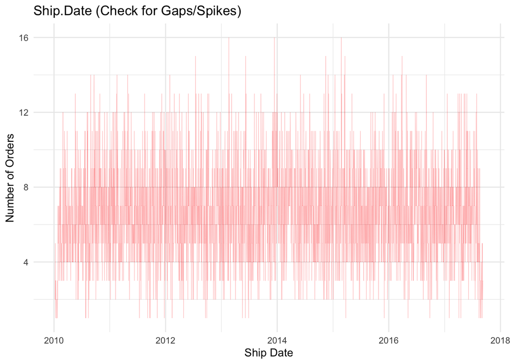

```r
ggplot(fixedCountries, aes(x = Ship.Date)) +
  geom_line(stat = "count", color = "red", linewidth = .05) +  # Count orders per date
  labs(
    title = "Ship.Date (Check for Gaps/Spikes)",
    x = "Ship Date",
    y = "Number of Orders"
  ) +
  theme_minimal()
```

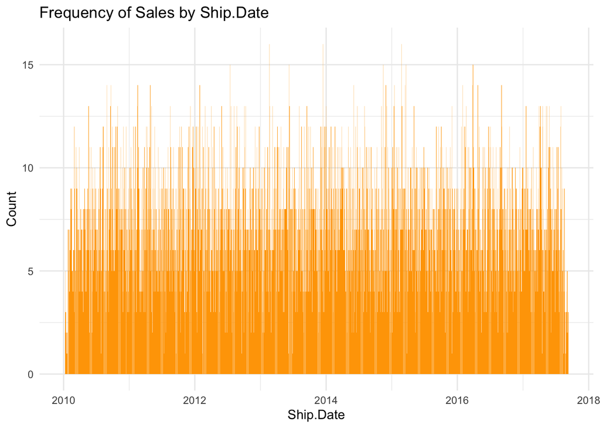

```r
channel_counts <- fixedCountries %>%
  count(Ship.Date) %>%
  arrange(desc(n))  # Sort by frequency (descending)

ggplot(channel_counts, aes(x = Ship.Date, y = n)) +
  geom_bar(stat = "identity", fill = "orange") +
  labs(title = "Frequency of Sales by Ship.Date", x = "Ship.Date", y = "Count") +
  theme_minimal()
```

#——————————— Order.ID

```r
fixedCountries$Order.ID <- as.integer(fixedCountries$Order.ID)
summary(fixedCountries$Order.ID)
```

```
##      Min.   1st Qu.    Median      Mean   3rd Qu.      Max.
## 100008904 329377472 547691476 551677367 778671300 999960410
```

#——————————— Units.Sold

```r
fixedCountries$Units.Sold <- as.integer(fixedCountries$Units.Sold)
summary(fixedCountries$Units.Sold)
```

```
##    Min. 1st Qu.  Median    Mean 3rd Qu.    Max.
##       1    2490    4962    4962    7430   10000
```

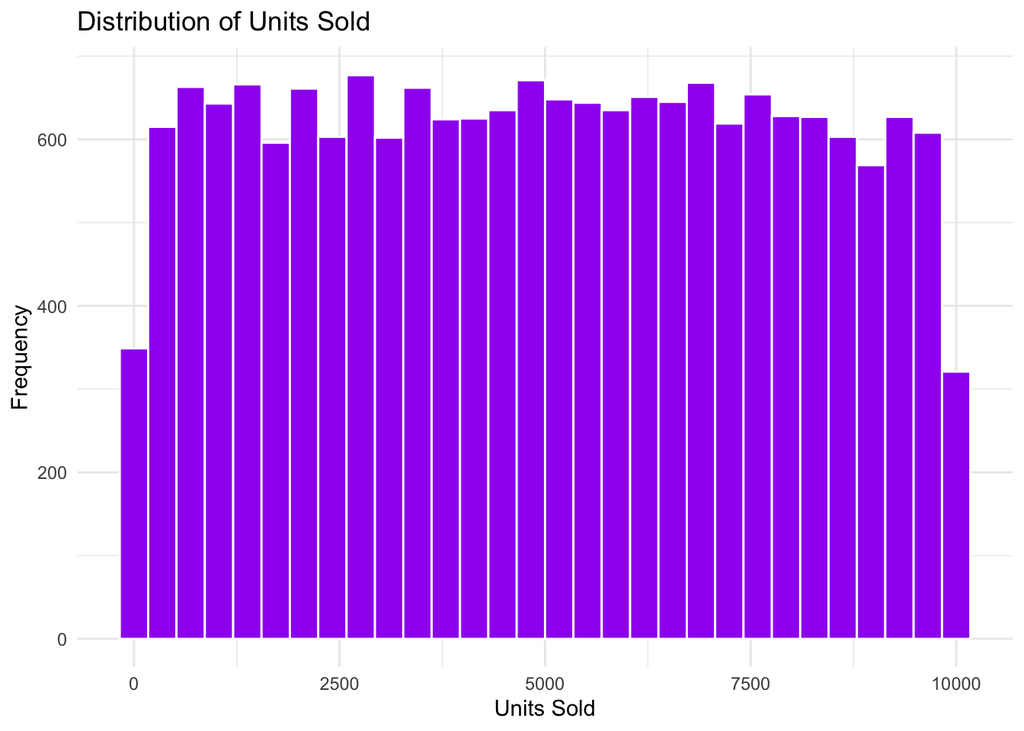

```r
ggplot(fixedCountries, aes(x = Units.Sold)) +
  geom_histogram(bins = 30, fill = "purple", color = "white") +
  labs(title = "Distribution of Units Sold", x = "Units Sold", y = "Frequency") +
  theme_minimal()
```

#———————————- Unit.Cost

```r
fixedCountries$Unit.Cost <- as.numeric(fixedCountries$Unit.Cost)
summary(fixedCountries$Unit.Cost)
```

```
##    Min. 1st Qu.  Median    Mean 3rd Qu.    Max.
##    6.92   35.84   97.44  187.26  263.33  524.96
```

[figure not shown]

```r
# Boxplot for Unit.Price
ggplot(fixedCountries, aes(y = Unit.Price)) +
  geom_boxplot(fill = "lightgreen") +
  labs(title = "Boxplot of Unit Price")
```

[figure not shown]

```r
# Scatter Plot: Unit.Price vs. Unit.Cost (should generally be above the diagonal)
ggplot(fixedCountries, aes(x = Unit.Cost, y = Unit.Price)) +
  geom_point(color = "blue") +
  geom_abline(slope = 1, linetype = "dashed", color = "red") +  # Profit=0% line
  labs(title = "Unit Price vs. Unit Cost (Check for Pricing Errors)")
```

#———————————- Total.Cost

```r
fixedCountries$Total.Cost <- as.numeric(fixedCountries$Total.Cost)
summary(fixedCountries$Total.Cost)
```

```
##    Min. 1st Qu.  Median    Mean 3rd Qu.    Max.
##      21  161975  456590  929572 1187046 5248550
```

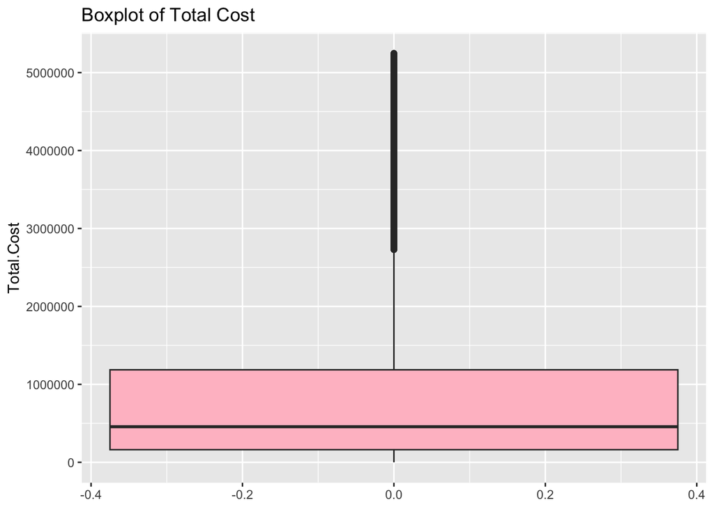

```r
# Boxplot
ggplot(fixedCountries, aes(y = Total.Cost)) +
  geom_boxplot(fill = "pink") +
  labs(title = "Boxplot of Total Cost")
```

[figure not shown]

```r
# Scatter Plot: Total.Cost vs. Total.Revenue
ggplot(fixedCountries, aes(x = Total.Cost, y = Total.Revenue)) +
  geom_point(color = "darkgreen") +
  geom_abline(slope = .05, linetype = "dashed", color = "red") +  # For every $1 of Total.Cost, you expect $0.05 of Total.Revenue to break even.
  labs(title = "Total Cost vs. Total Revenue (Should Mostly Be Below Diagonal)")
```

#————————- Total.Revenue

```r
fixedCountries$Total.Revenue <- as.numeric(fixedCountries$Total.Revenue)
summary(fixedCountries$Total.Revenue)
```

```
##    Min. 1st Qu.  Median    Mean 3rd Qu.    Max.    NA's
##      28  277404  778653 1321144 1818681 6679359     104
```

#— Using fixedCountries$Total.Profit + fixedCountries$Total.Cost = fixedCountries$Total.Revenue to replace the NA’s

```r
fixedCountries$Total.Profit <- as.numeric(fixedCountries$Total.Profit)

fixedCountries$Total.Revenue <- ifelse(is.na(fixedCountries$Total.Revenue) & !is.na(fixedCountries$Total.Cost) & !is.na(fixedCountries$Total.Profit),
                          fixedCountries$Total.Profit + fixedCountries$Total.Cost,
                          fixedCountries$Total.Revenue)

summary(fixedCountries$Total.Revenue)
```

```
##    Min. 1st Qu.  Median    Mean 3rd Qu.    Max.
##      28  277640  778311 1320920 1816022 6679359
```

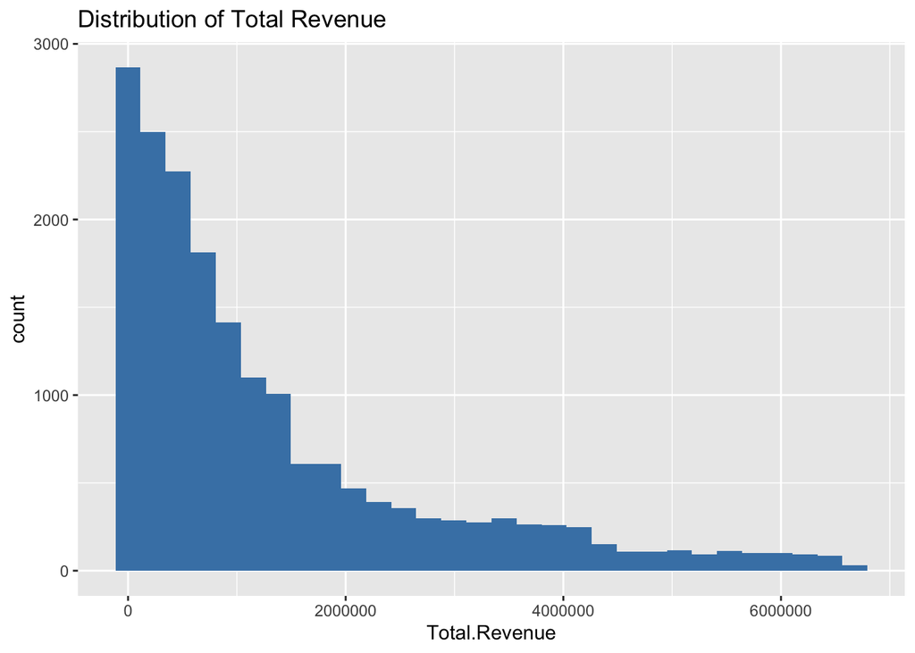

```r
# Histogram
ggplot(fixedCountries, aes(x = Total.Revenue)) +
  geom_histogram(bins = 30, fill = "steelblue") +
  labs(title = "Distribution of Total Revenue")
```

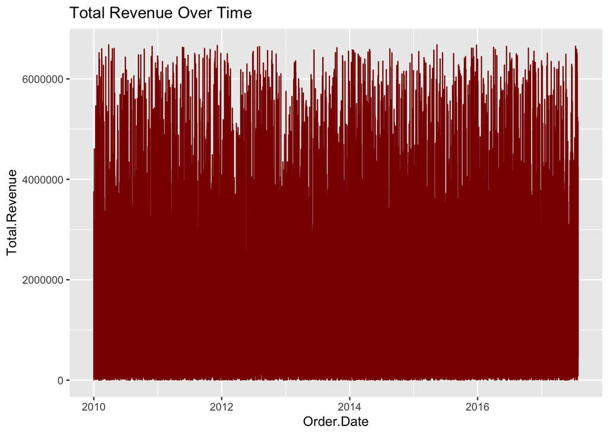

```r
# Time Series (if Order.Date exists)
fixedCountries$Order.Date <- as.Date(fixedCountries$Order.Date)  # Convert to date
ggplot(fixedCountries, aes(x = Order.Date, y = Total.Revenue)) +
  geom_line(color = "darkred") +
  labs(title = "Total Revenue Over Time")
```

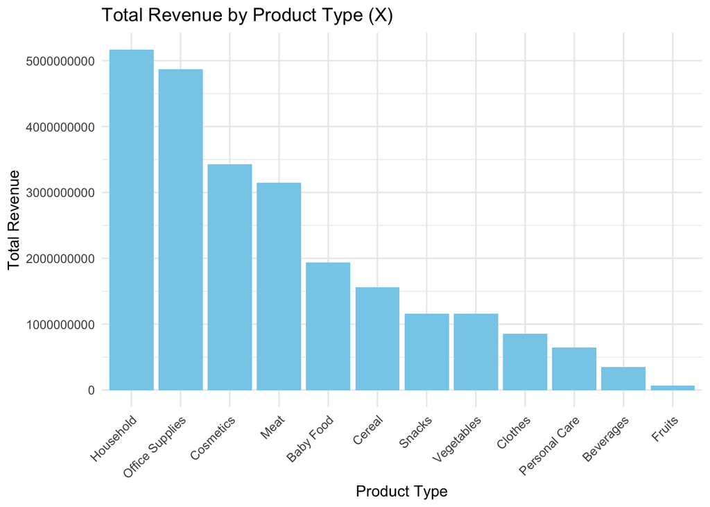

```r
revenue_by_product <- fixedCountries %>%
  group_by(X) %>%
  summarise(Total_Revenue = sum(Total.Revenue, na.rm = TRUE)) %>%
  arrange(desc(Total_Revenue))  # Sort by highest revenue

ggplot(revenue_by_product, aes(x = reorder(X, -Total_Revenue), y = Total_Revenue)) +
  geom_bar(stat = "identity", fill = "skyblue") +
  labs(
    title = "Total Revenue by Product Type (X)",
    x = "Product Type",
    y = "Total Revenue"
  ) +
  theme_minimal() +
  theme(axis.text.x = element_text(angle = 45, hjust = 1))  # Rotate x-labels
```

#————————- Unit.Price

```r
fixedCountries$Unit.Price <- as.numeric(fixedCountries$Unit.Price)
summary(fixedCountries$Unit.Price)
```

```
##    Min. 1st Qu.  Median    Mean 3rd Qu.    Max.    NA's
##    9.33   81.73  154.06  266.02  437.20  668.27      82
```

#— Using fixedCountries$Total.Revenue / fixedCountries$Units.Sold = Unit.Price to replace the NA’s

```r
fixedCountries$Unit.Price <- ifelse(
  is.na(fixedCountries$Unit.Price) &
  !is.na(fixedCountries$Total.Revenue) &
  !is.na(fixedCountries$Units.Sold),
  fixedCountries$Total.Revenue / fixedCountries$Units.Sold,  # Calculate Unit.Price
  fixedCountries$Unit.Price  # Keep original value if not NA
)

summary(fixedCountries$Unit.Price)
```

```
##    Min. 1st Qu.  Median    Mean 3rd Qu.    Max.
##    9.33   81.73  154.06  266.02  437.20  668.27
```

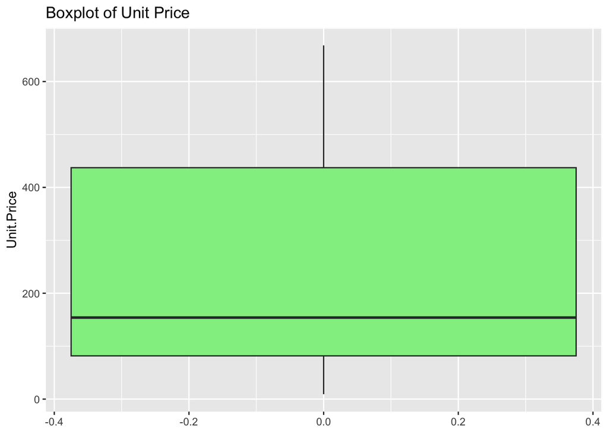

```r
# Boxplot for Unit.Price
ggplot(fixedCountries, aes(y = Unit.Price)) +
  geom_boxplot(fill = "lightgreen") +
  labs(title = "Boxplot of Unit Price")
```

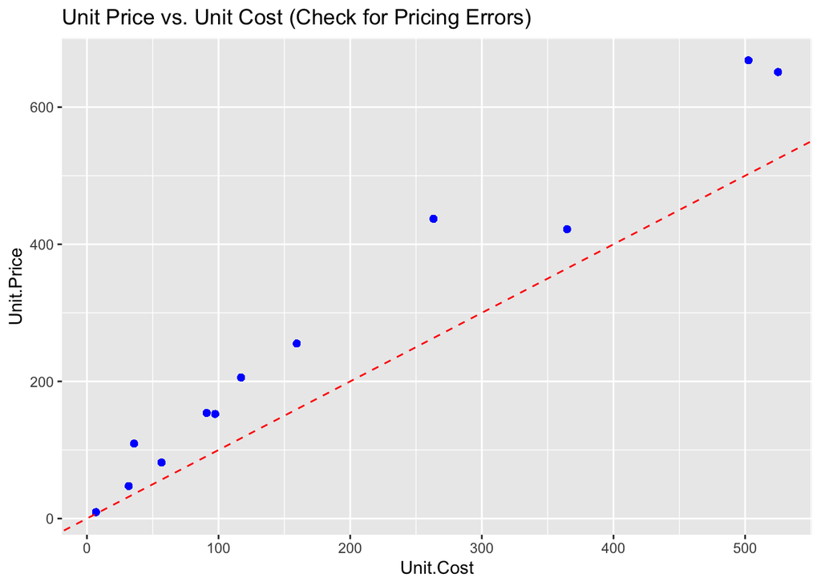

```r
# Scatter Plot: Unit.Price vs. Unit.Cost (should generally be above the diagonal)
ggplot(fixedCountries, aes(x = Unit.Cost, y = Unit.Price)) +
  geom_point(color = "blue") +
  geom_abline(slope = 1, linetype = "dashed", color = "red") +  # Profit=0 line
  labs(title = "Unit Price vs. Unit Cost (Check for Pricing Errors)")
```

#————————- Total.Profit

```r
fixedCountries$Total.Profit <- as.numeric(fixedCountries$Total.Profit)
summary(fixedCountries$Total.Profit)
```

```
##      Min.   1st Qu.    Median      Mean   3rd Qu.      Max.      NA's
##       7.2   95578.8  278964.4  391441.9  566781.1 1737309.0       178
```

#— Using fixedCountries$Total.Revenue - fixedCountries$Total.Cost = Total.Profit to replace the NA’s

```r
fixedCountries$Total.Profit <- ifelse(is.na(fixedCountries$Total.Profit) & !is.na(fixedCountries$Total.Revenue) & !is.na(fixedCountries$Total.Cost),
                          fixedCountries$Total.Revenue - fixedCountries$Total.Cost,
                          fixedCountries$Total.Profit)

summary(fixedCountries$Total.Profit)
```

```
##      Min.   1st Qu.    Median      Mean   3rd Qu.      Max.
##       7.2   95737.4  278677.6  391348.1  566800.7 1737309.0
```

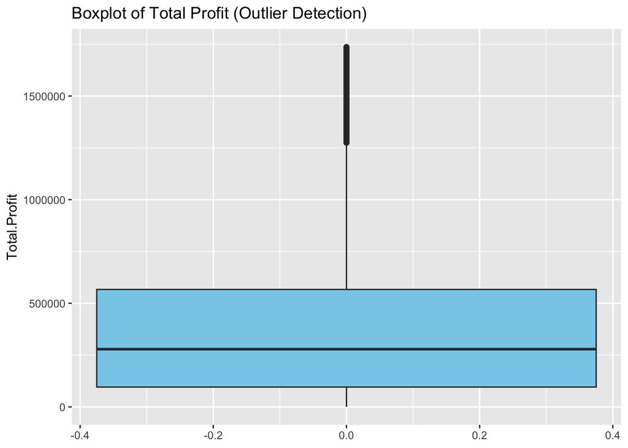

```r
# Boxplot (identify extreme values)
ggplot(fixedCountries, aes(y = Total.Profit)) +
  geom_boxplot(fill = "skyblue") +
  labs(title = "Boxplot of Total Profit (Outlier Detection)")
```

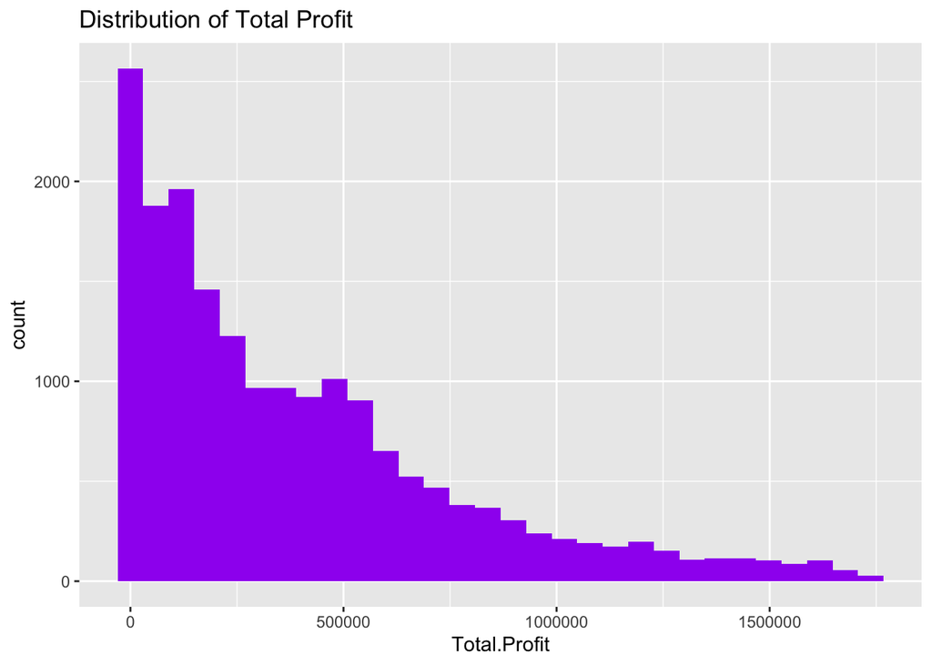

```r
# Histogram (check distribution)
ggplot(fixedCountries, aes(x = Total.Profit)) +
  geom_histogram(bins = 30, fill = "purple") +
  labs(title = "Distribution of Total Profit")
```

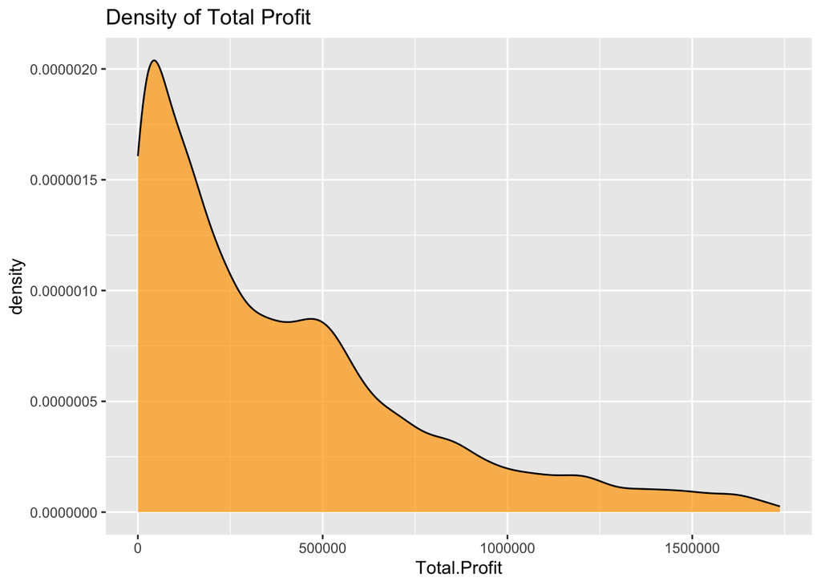

```r
# Density plot (smooth distribution)
ggplot(fixedCountries, aes(x = Total.Profit)) +
  geom_density(fill = "orange", alpha = 0.7) +
  labs(title = "Density of Total Profit")
```

#————————-

```r
cleanData.df = fixedCountries
```

#———————— PART 3

# What is the average amount spent on Personal Care vs. Cosmetics in each region?

```r
#Clean up data
#rm(list=ls())
#options(scipen=9999)

sales.df = cleanData.df


#Convert Revenue to numeric
sales.df$Total.Revenue <- as.numeric(sales.df$Total.Revenue)

#Create dataframes for Personal Care and Cosmetics
caredata <- subset(sales.df, X == "Personal Care")


cosmeticsdata <- subset(sales.df, X == "Cosmetics")


careavg <- mean(caredata$Total.Revenue, na.rm = TRUE)
cosmeticsavg <- mean(cosmeticsdata$Total.Revenue, na.rm = TRUE)

cat("The average money spent on Personal care is", careavg, "while the average spent on Cosmetics is", cosmeticsavg)
```

```
## The average money spent on Personal care is 411778.7 while the average spent on Cosmetics is 2188348
```

# In which country do people use the most cosmetics?

```r
#Convert Revenue to numeric
cosmeticsdata$Units.Sold <- as.numeric(cosmeticsdata$Units.Sold)

#Get sums the units sold in each country
cosmeticsum <- aggregate(Units.Sold ~ Country, data = cosmeticsdata, FUN = sum, na.rm = TRUE)

#Gets the data for the country with the maximum units sold
cosmax <- cosmeticsum[which.max(cosmeticsum$Units.Sold), ]
cat("People use the most cosmetics in", cosmax$Country)
```

```
## People use the most cosmetics in Austria
```

# In 2016, which product had the highest and lowest quantity sold across each region?

```r
#Set datatypes
sales.df$Order.Date <- as.Date(sales.df$Order.Date, format = "%d/%m/%Y")
sales.df$Units.Sold <- as.numeric(sales.df$Units.Sold)

#Create subset of data from 2016
data2016 <- subset(sales.df, format(Order.Date, "%Y") == "2016")

#Find total per region and per product
total <- aggregate(Units.Sold ~ Region + X, data = data2016, sum, na.rm = TRUE)

#Split data by regions
byregions <- split(total, total$Region)

#Create a dataframe with the maximums and minimums found from byregions

hilo <- lapply(byregions, function(df) {
  data.frame(
    Region = unique(df$Region),
    Highest.Sold = df$X[which.max(df$Units.Sold)],
    Lowest.Sold = df$X[which.min(df$Units.Sold)]
  )
})

hilo <- do.call(rbind, hilo)
print(hilo)
```

```
##                                                              Region
## Asia                                                           Asia
## Australia and Oceania                         Australia and Oceania
## Central America and the Caribbean Central America and the Caribbean
## Europe                                                       Europe
## Middle East and North Africa           Middle East and North Africa
## North America                                         North America
## Sub-Saharan Africa                               Sub-Saharan Africa
##                                   Highest.Sold Lowest.Sold
## Asia                                   Clothes   Beverages
## Australia and Oceania                  Clothes      Fruits
## Central America and the Caribbean         Meat   Cosmetics
## Europe                               Household      Snacks
## Middle East and North Africa            Snacks        Meat
## North America                             Meat      Cereal
## Sub-Saharan Africa                  Vegetables        Meat
```

# What is the average profit for each item by region?

```r
#Set datatypes
sales.df$Total.Profit <- as.numeric(sales.df$Total.Profit)

aggregate(Total.Profit ~ Region + X, data = sales.df, FUN = mean, na.rm = TRUE)
```

```
##                               Region               X Total.Profit
## 1                               Asia       Baby Food    466167.18
## 2              Australia and Oceania       Baby Food    473826.99
## 3  Central America and the Caribbean       Baby Food    489773.41
## 4                             Europe       Baby Food    457162.93
## 5       Middle East and North Africa       Baby Food    491172.79
## 6                      North America       Baby Food    455639.01
## 7                 Sub-Saharan Africa       Baby Food    472617.85
## 8                               Asia       Beverages     74518.61
## 9              Australia and Oceania       Beverages     80224.61
## 10 Central America and the Caribbean       Beverages     76929.80
## 11                            Europe       Beverages     77083.99
## 12      Middle East and North Africa       Beverages     75667.93
## 13                     North America       Beverages     82947.99
## 14                Sub-Saharan Africa       Beverages     78142.55
```

[output cut: 70 more lines]

# In which of the seasons (Spring, Summer, Autumn, Winter) do people spend the most on:

Cosmetics Personal Care

```r
#Note that we will use the same seasons for all regions, and assume typical Northern Hemisphere Seasons where, generally
#Winter is December, January and February
#Spring is March, April and May
#Summer is June, July and August
#Autumn is September, October, November

#Set datatypes
sales.df$Month <- as.numeric(format(sales.df$Order.Date, "%m"))

#Create bins labelled as seasons, and assign months to seasons
sales.df$Season <- cut(sales.df$Month,
                       breaks = c(0, 2, 5, 8, 11, 12),
                       labels = c("Winter", "Spring", "Summer", "Autumn", "Winter"),
                       include.lowest = TRUE, right = TRUE)

#Create an aggregate of revenue by season
seasonsales <- aggregate(Total.Revenue ~ Season + X, data = sales.df[sales.df$X %in% c("Cosmetics", "Personal Care"), ], sum, na.rm = TRUE)


#Set datatypes
seasonsales$Season <- as.character(seasonsales$Season)

#Get maximums
maxcos <- seasonsales$Season[which.max(seasonsales$Total.Revenue[seasonsales$X == "Cosmetics"])]
maxcare <- seasonsales$Season[which.max(seasonsales$Total.Revenue[seasonsales$X == "Personal Care"])]

cat("Highest spending on cosmetics was in", maxcos, "and highest spending on personal care was in", maxcare)
```

```
## Highest spending on cosmetics was in Winter and highest spending on personal care was in Winter
```

# Find the monthly average units sold for Personal Care, Cosmetics and Beverages and plot a series graph for ONE year . Discuss the resulting visualization.

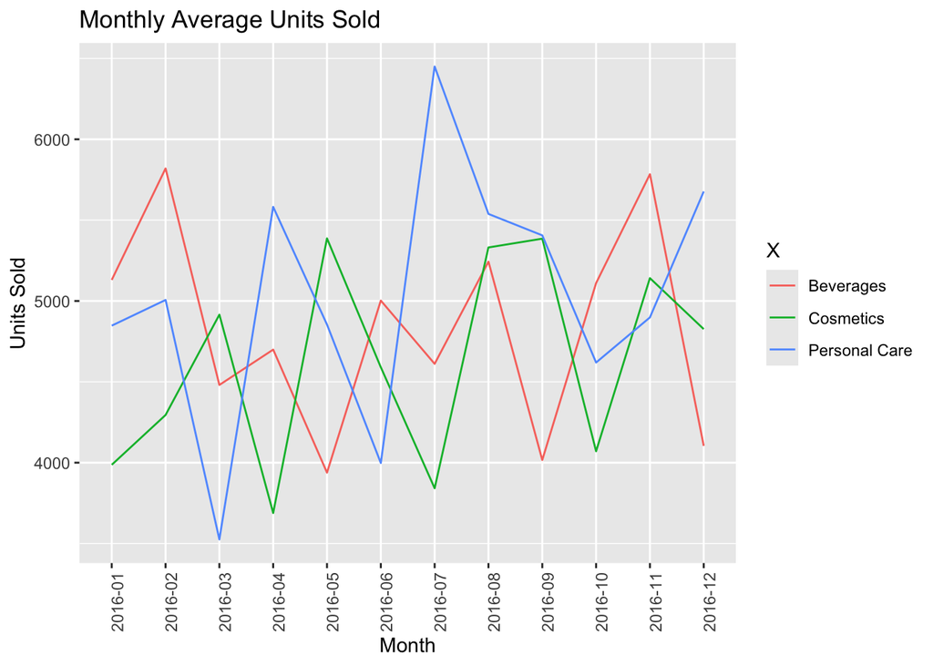

```r
#Remove days
data2016$YearMonth <- format(data2016$Order.Date, "%Y-%m")

#Create subset with only the needed data
data2016filter<- data2016[data2016$X %in% c("Personal Care", "Cosmetics", "Beverages"), ]

#Find monthly average
monthlyavg <- aggregate(Units.Sold ~ YearMonth + X, data = data2016filter, FUN = mean, na.rm = TRUE)

#Plot line graph
ggplot(monthlyavg, aes(x = YearMonth, y = Units.Sold, color = X, group = X)) + geom_line() + labs(title = "Monthly Average Units Sold", x = "Month", y = "Units Sold") +
  theme(axis.text.x = element_text(angle = 90, hjust = 1))
```

# Determine correlation between Total.Profit and the other features (include visualizations) in the dataset.

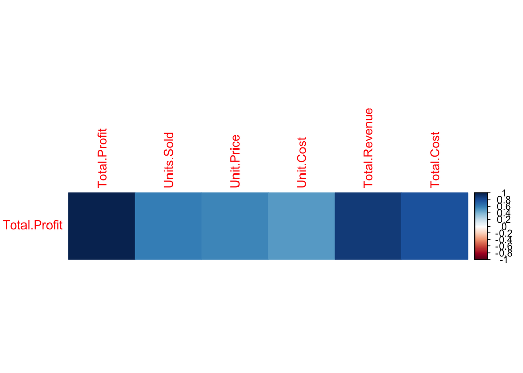

```r
#Set datatypes
salesg.df <- sales.df %>% select(Total.Profit, Units.Sold, Unit.Price, Unit.Cost, Total.Revenue, Total.Cost) %>%mutate(across(everything(), as.numeric))

#Create correlation matrix
num_cols <- sapply(salesg.df, is.numeric)
cor_matrix <- cor(salesg.df[, num_cols], use = "complete.obs")
profit_corr <- cor_matrix["Total.Profit", , drop = FALSE]

#Visualize correlation with Profit
corrplot(profit_corr, method = "color")
```

```r
#Check correlations
cor(salesg.df$Units.Sold,sales.df$Total.Profit)
```

```
## [1] 0.6010744
```

```r
cor(salesg.df$Unit.Price,sales.df$Total.Profit)
```

```
## [1] 0.5769989
```

```r
cor(salesg.df$Unit.Cost,sales.df$Total.Profit)
```

```
## [1] 0.5044471
```

```r
cor(salesg.df$Total.Revenue,sales.df$Total.Profit)
```

```
## [1] 0.8806453
```

```r
cor(salesg.df$Total.Cost,sales.df$Total.Profit)
```

```
## [1] 0.7952496
```

# Based on correlation from part (g), build a predictive model that can be used to predict Total.Profit. Determine the accuracy of the model and show the result of a sample set of predictions for data not included in the given dataset.

```r
#Split data into training and testing
set.seed(101)
train <- (sample(1:nrow(sales.df),nrow(sales.df)*0.8))
training <- sales.df[train,]
testing <- sales.df[-train,]

#Model
result <- result <- lm(Total.Profit ~ Units.Sold + Unit.Price + Unit.Cost + Total.Revenue + Total.Cost, data = sales.df)
summary(result)
```

```
##
## Call:
## lm(formula = Total.Profit ~ Units.Sold + Unit.Price + Unit.Cost +
##     Total.Revenue + Total.Cost, data = sales.df)
##
## Residuals:
##            Min             1Q         Median             3Q            Max
## -0.00000071812 -0.00000000017 -0.00000000006  0.00000000007  0.00000109589
##
## Coefficients:
##                             Estimate             Std. Error
## (Intercept)   -0.0000000049278112711  0.0000000002657449604
## Units.Sold     0.0000000000012684093  0.0000000000000464926
## Unit.Price     0.0000000000738390077  0.0000000000041047523
## Unit.Cost     -0.0000000000592908274  0.0000000000050681659
## Total.Revenue  0.9999999999999903411  0.0000000000000007139
## Total.Cost    -0.9999999999999882316  0.0000000000000008807
##                            t value            Pr(>|t|)
## (Intercept)                 -18.54 <0.0000000000000002 ***
## Units.Sold                   27.28 <0.0000000000000002 ***
## Unit.Price                   17.99 <0.0000000000000002 ***
## Unit.Cost                   -11.70 <0.0000000000000002 ***
## Total.Revenue  1400848579289693.50 <0.0000000000000002 ***
## Total.Cost    -1135453013174722.50 <0.0000000000000002 ***
## ---
## Signif. codes:  0 '***' 0.001 '**' 0.01 '*' 0.05 '.' 0.1 ' ' 1
##
## Residual standard error: 0.00000001005 on 18433 degrees of freedom
## Multiple R-squared:      1,  Adjusted R-squared:      1
## F-statistic: 5.217e+30 on 5 and 18433 DF,  p-value: < 0.00000000000000022
```

```r
#Accuracy
testing$predictions <- as.integer(predict(result,testing))
sum(ifelse(abs(testing$Total.Profit-testing$predictions)<=5,1,0))/nrow(testing)*100
```

```
## [1] 100
```

# Explain how this model may help the investors make better decisions.

Investors could use this model to predict profits. This is especially useful when deciding how much of a product should be purchased, and how that may translate to future profits